# 沪深300增强和中证500增强

## 300增强500增强概况

目前市场上指数增强基金接近60只，其中号称指数增强但没有实现增强的不少。目前指数增强基金的主战场在沪深300增强和中证500增强上，市场上沪深300增强基金有22只，中证500增强基金有15只，具体情况如下表所示。这里新增了几个名义上不是指数增强基金，但其实做的是指数增强的事情。

09年首只沪深300指数增强基金国富沪深300成立，此后每年都有新的沪深300指数增强基金成立。而直到11年首只中证500增强基金富国中证500才成立，然后间隔了两年多，第二只中证500增强基金才成立。虽然我们回测的时候，中证500指数很容易做增强，但从基金的发行来看并非如此，稍后我们会看到第一只中证500增强基金前三年运行的并不如人意。

相比于沪深300和中证500，中证1000会是一个比较好的增强基金的基准，成分股数量足够多，毕竟在上证50里面做增强的难度远大于沪深300，目前也有两只中证1000的指数增强基金。未来随着中证1000的估值进一步下降，这个指数的吸引力会比较大。

| fundID | fundName | setupdate | trackindexcode |
| --- | --- | --- | --- |
| 450008.OF | 国富沪深300 | 2009-09-03 | EI000300 |
| 100038.OF | 富国沪深300 | 2009-12-16 | EI000300 |
| 166007.OF | 中欧沪深300A | 2010-06-24 | EI000300 |
| 163407.OF | 兴全沪深300 | 2010-11-02 | EI000300 |
| 519116.OF | 浦银安盛沪深300 | 2010-12-10 | EI000300 |
| 200002.OF | 长城久泰沪深300 | 2011-04-01 | EI000300 |
| 110030.OF | 易方达沪深300量化 | 2012-07-05 | EI000300 |
| 310318.OF | 申万菱信沪深300 | 2013-06-08 | EI000300 |
| 000312.OF | 华安沪深300量化A | 2013-09-27 | EI000300 |
| 000311.OF | 景顺长城沪深300 | 2013-10-29 | EI000300 |
| 000877.OF | 华泰柏瑞量化优选 | 2014-12-17 | EI000300 |
| 000176.OF | 嘉实沪深300增强 | 2014-12-26 | EI000300 |
| 001015.OF | 华夏沪深300A | 2015-02-10 | EI000300 |
| 001074.OF | 华泰柏瑞量化驱动 | 2015-03-24 | EI000300 |
| 002310.OF | 创金合信沪深300A | 2015-12-31 | EI000300 |
| 003015.OF | 中金沪深300A | 2016-07-22 | EI000300 |
| 003261.OF | 安信沪深300A | 2016-10-12 | EI000300 |
| 003876.OF | 华宝沪深300 | 2016-12-09 | EI000300 |
| 004190.OF | 招商沪深300A | 2017-02-10 | EI000300 |
| 003311.OF | 大摩睿成大盘弹性 | 2017-04-12 | EI000300 |
| 167601.OF | 国金沪深300 | 2017-09-01 | EI000300 |
| 005113.OF | 平安大华沪深300指数量化A | 2017-12-26 | EI000300 |
| 460009.OF | 华泰柏瑞量化先行 | 2010-06-22 | EI000905 |
| 161017.OF | 富国中证500 | 2011-10-12 | EI000905 |
| 000478.OF | 建信中证500 | 2014-01-27 | EI000905 |
| 000978.OF | 景顺长城量化精选 | 2015-02-04 | EI000905 |
| 001244.OF | 华泰柏瑞量化智慧 | 2015-06-03 | EI000905 |
| 002311.OF | 创金合信中证500A | 2015-12-31 | EI000905 |
| 002510.OF | 申万菱信中证500 | 2016-04-21 | EI000905 |
| 003016.OF | 中金中证500A | 2016-07-22 | EI000905 |
| 001733.OF | 泰达宏利量化 | 2016-08-30 | EI000905 |
| 002906.OF | 南方中证500增强A | 2016-11-23 | EI000905 |
| 003986.OF | 申万菱信中证500优选 | 2017-01-10 | EI000905 |
| 003312.OF | 大摩睿成中小盘弹性 | 2017-01-16 | EI000905 |
| 004192.OF | 招商中证500A | 2017-05-17 | EI000905 |
| 004945.OF | 长信中证500 | 2017-08-30 | EI000905 |
| 005062.OF | 博时中证500 | 2017-09-26 | EI000905 |

## 沪深300增强基金历年表现

指标说明bias是日偏离度绝对值的均值，TE是跟踪误差，alphaIR是日超额收益的信息比率，alphamaxDD是超额收益的最大回撤。

| date | fundName | rtn | bench | alpha | alphaIR | bias | TE | hitratio | alphamaxDD |
| --- | --- | --- | --- | --- | --- | --- | --- | --- | --- |
| 2011-12-30 | 富国沪深300 | -17.7% | -25.0% | 7.3% | 2.737 | 0.0014 | 2.7% | 58% | -1.2% |
| 2011-12-30 | 兴全沪深300 | -19.7% | -23.8% | 4.1% | 1.418 | 0.0015 | 3.2% | 53% | -2.3% |
| 2011-12-30 | 国富沪深300 | -22.7% | -25.0% | 2.3% | 1.030 | 0.0011 | 2.2% | 55% | -2.8% |
| 2011-12-30 | 中欧沪深300A | -23.0% | -25.0% | 2.1% | 1.062 | 0.0010 | 2.0% | 53% | -2.5% |
| 2011-12-30 | 长城久泰沪深300 | -21.6% | -22.9% | 1.3% | 1.549 | 0.0006 | 1.3% | 62% | -0.7% |
| 2011-12-30 | 浦银安盛沪深300 | -29.5% | -29.7% | 0.2% | 0.103 | 0.0011 | 2.3% | 48% | -1.6% |
| 2012-12-31 | 富国沪深300 | 12.6% | 7.6% | 5.1% | 2.242 | 0.0011 | 2.3% | 56% | -1.8% |
| 2012-12-31 | 国富沪深300 | 12.6% | 7.6% | 5.1% | 2.084 | 0.0011 | 2.5% | 53% | -2.0% |
| 2012-12-31 | 兴全沪深300 | 9.4% | 7.6% | 1.9% | 0.692 | 0.0013 | 2.7% | 50% | -2.4% |
| 2012-12-31 | 浦银安盛沪深300 | 8.8% | 7.6% | 1.3% | 0.639 | 0.0010 | 2.0% | 54% | -1.6% |
| 2012-12-31 | 长城久泰沪深300 | 7.9% | 7.6% | 0.4% | 0.275 | 0.0006 | 1.3% | 55% | -1.4% |
| 2012-12-31 | 中欧沪深300A | 6.6% | 7.6% | -1.0% | -0.563 | 0.0009 | 1.8% | 50% | -2.4% |
| 2013-12-31 | 易方达沪深300量化 | -3.4% | -7.8% | 4.4% | 2.264 | 0.0013 | 3.3% | 56% | -0.8% |
| 2013-12-31 | 兴全沪深300 | -4.6% | -7.6% | 3.0% | 0.930 | 0.0017 | 3.3% | 52% | -2.7% |
| 2013-12-31 | 中欧沪深300A | -4.7% | -7.6% | 3.0% | 1.658 | 0.0009 | 1.8% | 57% | -0.9% |
| 2013-12-31 | 申万菱信沪深300 | 1.2% | -1.2% | 2.4% | 1.520 | 0.0024 | 5.0% | 59% | -2.2% |
| 2013-12-31 | 长城久泰沪深300 | -6.2% | -7.6% | 1.5% | 1.089 | 0.0006 | 1.4% | 55% | -1.2% |
| 2013-12-31 | 华安沪深300量化A | 2.9% | 2.9% | 0.0% | 0.872 | 0.0009 | 1.9% | 33% | -0.1% |
| 2013-12-31 | 国富沪深300 | -7.7% | -7.6% | -0.1% | -0.022 | 0.0015 | 3.2% | 49% | -3.0% |
| 2013-12-31 | 浦银安盛沪深300 | -7.7% | -7.6% | -0.1% | -0.032 | 0.0014 | 2.9% | 51% | -3.7% |
| 2013-12-31 | 富国沪深300 | -8.4% | -7.6% | -0.7% | -0.276 | 0.0014 | 2.7% | 50% | -3.1% |
| 2014-12-31 | 申万菱信沪深300 | 57.9% | 51.7% | 6.2% | 1.279 | 0.0023 | 4.9% | 53% | -5.1% |
| 2014-12-31 | 兴全沪深300 | 57.2% | 51.7% | 5.5% | 1.867 | 0.0014 | 3.0% | 49% | -3.7% |
| 2014-12-31 | 易方达沪深300量化 | 55.9% | 51.7% | 4.3% | 1.423 | 0.0013 | 3.0% | 53% | -4.5% |
| 2014-12-31 | 富国沪深300 | 55.4% | 51.7% | 3.7% | 1.377 | 0.0013 | 2.7% | 54% | -4.1% |
| 2014-12-31 | 景顺长城沪深300 | 62.0% | 59.2% | 2.9% | 0.871 | 0.0017 | 3.7% | 50% | -3.2% |
| 2014-12-31 | 中欧沪深300A | 51.5% | 51.7% | -0.2% | -0.074 | 0.0011 | 2.7% | 52% | -4.3% |
| 2014-12-31 | 长城久泰沪深300 | 49.1% | 51.7% | -2.5% | -1.764 | 0.0006 | 1.5% | 50% | -3.5% |
| 2014-12-31 | 浦银安盛沪深300 | 47.9% | 51.7% | -3.7% | -1.484 | 0.0012 | 2.5% | 48% | -4.2% |
| 2014-12-31 | 国富沪深300 | 47.4% | 51.7% | -4.2% | -1.586 | 0.0012 | 2.7% | 52% | -5.3% |

[output cut: 73 more lines]

## 中证500增强基金历年表现

| date | fundName | rtn | bench | alpha | alphaIR | bias | TE | hitratio | alphamaxDD |
| --- | --- | --- | --- | --- | --- | --- | --- | --- | --- |
| 2011-12-30 | 华泰柏瑞量化先行 | -22.5% | -33.8% | 11.3% | 1.087 | 0.0047 | 10.5% | 48% | -7.0% |
| 2012-12-31 | 华泰柏瑞量化先行 | 8.1% | 0.3% | 7.8% | 0.690 | 0.0054 | 11.4% | 48% | -12.3% |
| 2012-12-31 | 富国中证500 | 5.2% | -2.1% | 7.3% | 2.646 | 0.0014 | 2.8% | 56% | -1.2% |
| 2013-12-31 | 富国中证500 | 16.6% | 16.9% | -0.3% | -0.089 | 0.0016 | 3.2% | 49% | -3.3% |
| 2013-12-31 | 华泰柏瑞量化先行 | 8.0% | 16.9% | -8.9% | -0.794 | 0.0054 | 11.4% | 40% | -15.3% |
| 2014-12-31 | 建信中证500 | 40.7% | 40.0% | 0.7% | 0.389 | 0.0015 | 3.1% | 50% | -3.1% |
| 2014-12-31 | 富国中证500 | 38.7% | 39.0% | -0.3% | -0.094 | 0.0015 | 3.2% | 44% | -4.1% |
| 2014-12-31 | 华泰柏瑞量化先行 | 6.4% | 39.0% | -32.6% | -3.417 | 0.0047 | 9.6% | 39% | -27.1% |
| 2015-12-31 | 华泰柏瑞量化先行 | 69.1% | 43.1% | 26.0% | 2.816 | 0.0038 | 9.4% | 56% | -6.3% |
| 2015-12-31 | 建信中证500 | 64.4% | 43.1% | 21.3% | 3.930 | 0.0025 | 5.5% | 61% | -5.4% |
| 2015-12-31 | 华泰柏瑞量化智慧 | 32.4% | 24.4% | 8.0% | 5.341 | 0.0041 | 8.2% | 52% | -4.5% |
| 2015-12-31 | 景顺长城量化精选 | -5.4% | -10.1% | 4.6% | 0.616 | 0.0045 | 10.9% | 61% | -10.3% |
| 2015-12-31 | 富国中证500 | 47.0% | 43.1% | 3.9% | 0.556 | 0.0026 | 7.2% | 51% | -7.7% |
| 2016-12-30 | 建信中证500 | 1.2% | -17.8% | 18.9% | 5.461 | 0.0016 | 3.5% | 69% | -0.8% |
| 2016-12-30 | 华泰柏瑞量化智慧 | 0.4% | -17.8% | 18.2% | 3.393 | 0.0025 | 5.4% | 58% | -1.7% |
| 2016-12-30 | 华泰柏瑞量化先行 | -0.7% | -17.8% | 17.1% | 3.156 | 0.0025 | 5.5% | 59% | -2.0% |
| 2016-12-30 | 景顺长城量化精选 | -2.3% | -17.8% | 15.5% | 3.949 | 0.0020 | 4.0% | 59% | -1.3% |
| 2016-12-30 | 富国中证500 | -6.2% | -17.8% | 11.6% | 3.270 | 0.0018 | 3.6% | 57% | -1.3% |
| 2016-12-30 | 创金合信中证500A | 8.0% | 2.1% | 6.0% | 2.419 | 0.0016 | 3.4% | 58% | -1.4% |
| 2016-12-30 | 申万菱信中证500 | -0.0% | -2.4% | 2.4% | 1.042 | 0.0023 | 5.1% | 55% | -4.8% |
| 2016-12-30 | 中金中证500A | -2.8% | -3.3% | 0.5% | 1.587 | 0.0008 | 1.5% | 54% | -0.8% |
| 2016-12-30 | 泰达宏利量化 | -6.2% | -5.4% | -0.8% | -1.535 | 0.0015 | 3.3% | 48% | -1.1% |
| 2017-12-29 | 华泰柏瑞量化先行 | 19.3% | -0.2% | 19.5% | 4.378 | 0.0022 | 4.5% | 59% | -2.0% |
| 2017-12-29 | 华泰柏瑞量化智慧 | 17.8% | -0.2% | 18.0% | 4.019 | 0.0021 | 4.6% | 58% | -2.5% |
| 2017-12-29 | 申万菱信中证500优选 | 11.6% | -5.0% | 16.6% | 4.019 | 0.0026 | 5.8% | 57% | -1.9% |
| 2017-12-29 | 泰达宏利量化 | 13.9% | -0.2% | 14.2% | 3.601 | 0.0018 | 4.0% | 59% | -1.8% |
| 2017-12-29 | 景顺长城量化精选 | 11.9% | -0.2% | 12.1% | 2.656 | 0.0022 | 4.6% | 53% | -3.9% |
| 2017-12-29 | 创金合信中证500A | 11.3% | -0.2% | 11.5% | 3.150 | 0.0017 | 3.7% | 59% | -2.7% |
| 2017-12-29 | 南方中证500增强A | 7.4% | -3.5% | 10.9% | 2.716 | 0.0022 | 4.7% | 55% | -1.9% |
| 2017-12-29 | 富国中证500 | 9.2% | -0.2% | 9.4% | 3.396 | 0.0014 | 2.8% | 56% | -1.8% |
| 2017-12-29 | 中金中证500A | 6.8% | -0.2% | 7.0% | 2.203 | 0.0015 | 3.2% | 55% | -2.1% |
| 2017-12-29 | 建信中证500 | 3.2% | -0.2% | 3.4% | 1.361 | 0.0012 | 2.6% | 55% | -2.0% |
| 2017-12-29 | 大摩睿成中小盘弹性 | -1.3% | -4.2% | 3.0% | 1.527 | 0.0013 | 2.8% | 53% | -1.7% |
| 2017-12-29 | 申万菱信中证500 | 1.3% | -0.2% | 1.5% | 0.376 | 0.0020 | 4.0% | 48% | -5.0% |
| 2017-12-29 | 长信中证500 | 0.2% | -1.1% | 1.3% | 3.950 | 0.0017 | 3.8% | 55% | -0.5% |
| 2017-12-29 | 博时中证500 | 1.3% | 1.1% | 0.2% | 47.988 | 0.0010 | 2.2% | 75% | -0.1% |
| 2017-12-29 | 招商中证500A | -1.4% | -1.1% | -0.4% | -0.362 | 0.0013 | 2.6% | 46% | -1.1% |
| 2018-03-12 | 申万菱信中证500优选 | 5.1% | 0.7% | 4.4% | 3.659 | 0.0034 | 7.2% | 60% | -2.5% |
| 2018-03-12 | 申万菱信中证500 | 4.6% | 0.7% | 3.9% | 3.202 | 0.0035 | 7.2% | 58% | -2.1% |
| 2018-03-12 | 长信中证500 | 4.1% | 0.7% | 3.4% | 3.915 | 0.0026 | 5.1% | 56% | -2.5% |
| 2018-03-12 | 中金中证500A | 3.8% | 0.7% | 3.1% | 4.508 | 0.0019 | 4.0% | 60% | -1.7% |
| 2018-03-12 | 博时中证500 | 3.6% | 0.7% | 2.9% | 3.031 | 0.0026 | 5.5% | 56% | -2.0% |
| 2018-03-12 | 建信中证500 | 3.4% | 0.7% | 2.7% | 5.062 | 0.0014 | 3.1% | 58% | -0.7% |
| 2018-03-12 | 华泰柏瑞量化先行 | 3.0% | 0.7% | 2.3% | 2.402 | 0.0025 | 5.4% | 51% | -3.2% |
| 2018-03-12 | 景顺长城量化精选 | 2.9% | 0.7% | 2.2% | 2.443 | 0.0026 | 5.2% | 56% | -1.9% |
| 2018-03-12 | 创金合信中证500A | 2.8% | 0.7% | 2.1% | 2.742 | 0.0020 | 4.4% | 60% | -1.8% |
| 2018-03-12 | 华泰柏瑞量化智慧 | 2.5% | 0.7% | 1.8% | 1.846 | 0.0027 | 5.6% | 51% | -3.8% |
| 2018-03-12 | 富国中证500 | 2.4% | 0.7% | 1.7% | 2.261 | 0.0021 | 4.3% | 53% | -1.4% |
| 2018-03-12 | 泰达宏利量化 | 2.2% | 0.7% | 1.5% | 2.319 | 0.0018 | 3.5% | 56% | -1.3% |
| 2018-03-12 | 招商中证500A | 1.7% | 0.7% | 1.0% | 2.117 | 0.0013 | 2.6% | 49% | -0.9% |
| 2018-03-12 | 南方中证500增强A | 1.0% | 0.7% | 0.3% | 0.423 | 0.0019 | 3.8% | 47% | -2.2% |
| 2018-03-12 | 大摩睿成中小盘弹性 | 0.8% | 0.7% | 0.1% | 0.078 | 0.0021 | 4.2% | 51% | -3.3% |

## 历年累计表现

指标说明,rtn是累计收益，nyear表示统计区间共多少年，alphaIR是月度超额收益的IR，hitratio是月度胜率，rtn_min是月度最小超额收益，rtn_max是月度最大超额收益。

| fundName | nyear | rtn | rtn_ann | alpha_ann | alphamaxDD | alphaIR | hitratio | rtn_min | rtn_max | rtn_mindate | rtn_maxdate |
| --- | --- | --- | --- | --- | --- | --- | --- | --- | --- | --- | --- |
| 华泰柏瑞量化优选 | 3.0 | 62% | 17.5% | 13.8% | -8.1% | 1.853 | 78% | -3.3% | 7.8% | 2017-10-31 | 2015-06-30 |
| 景顺长城沪深300 | 4.1 | 162% | 26.3% | 10.1% | -3.2% | 2.279 | 76% | -1.7% | 3.7% | 2014-12-31 | 2016-07-29 |
| 华宝沪深300 | 1.0 | 27% | 26.8% | 7.3% | -2.0% | 2.559 | 62% | -0.9% | 1.9% | 2017-10-31 | 2017-06-30 |
| 易方达沪深300量化 | 4.8 | 120% | 18.0% | 7.2% | -5.1% | 1.653 | 67% | -3.2% | 4.5% | 2014-12-31 | 2017-07-31 |
| 华泰柏瑞量化驱动 | 2.7 | 5% | 1.7% | 7.0% | -8.9% | 1.267 | 68% | -3.1% | 3.9% | 2017-10-31 | 2017-07-31 |
| 申万菱信沪深300 | 4.5 | 127% | 19.9% | 6.7% | -7.6% | 1.262 | 64% | -2.3% | 4.9% | 2017-05-31 | 2014-12-31 |
| 华夏沪深300A | 2.8 | 9% | 3.1% | 6.5% | -2.6% | 1.889 | 71% | -1.2% | 2.2% | 2017-10-31 | 2015-09-30 |
| 富国沪深300 | 7.2 | 103% | 10.4% | 6.4% | -4.3% | 1.596 | 61% | -2.3% | 4.5% | 2014-11-28 | 2015-06-30 |
| 招商沪深300A | 0.8 | 28% | 34.0% | 5.9% | -1.3% | 2.309 | 64% | -0.6% | 1.7% | 2018-01-31 | 2017-06-30 |
| 兴全沪深300 | 7.1 | 96% | 9.9% | 5.7% | -6.5% | 1.448 | 66% | -2.2% | 4.6% | 2011-02-28 | 2015-06-30 |
| 嘉实沪深300增强 | 3.0 | 21% | 6.8% | 5.2% | -4.3% | 1.126 | 62% | -2.9% | 3.3% | 2015-04-30 | 2015-05-29 |
| 安信沪深300A | 1.2 | 30% | 25.3% | 5.2% | -5.6% | 1.015 | 67% | -2.6% | 2.7% | 2017-05-31 | 2017-06-30 |
| 创金合信沪深300A | 1.9 | 38% | 17.9% | 4.3% | -2.1% | 1.478 | 64% | -1.2% | 2.6% | 2016-11-30 | 2016-07-29 |
| 华安沪深300量化A | 4.2 | 107% | 18.8% | 3.5% | -14.7% | 0.568 | 54% | -5.7% | 5.8% | 2014-12-31 | 2017-07-31 |
| 浦银安盛沪深300 | 7.0 | 44% | 5.4% | 2.3% | -8.0% | 0.790 | 66% | -2.3% | 2.9% | 2015-04-30 | 2015-07-31 |
| 中欧沪深300A | 7.2 | 45% | 5.3% | 1.4% | -4.8% | 0.497 | 49% | -2.6% | 3.2% | 2014-12-31 | 2015-01-30 |
| 长城久泰沪深300 | 6.7 | 48% | 6.0% | 1.4% | -5.9% | 0.654 | 58% | -2.7% | 1.5% | 2014-12-31 | 2016-07-29 |
| 国富沪深300 | 7.2 | 38% | 4.6% | 0.7% | -8.6% | 0.204 | 45% | -3.7% | 3.1% | 2014-12-31 | 2012-06-29 |
| 国金沪深300 | 0.3 | 3% | 11.2% | -0.2% | -1.4% | -0.226 | 25% | -0.4% | 0.6% | 2018-01-31 | 2017-12-29 |
| 中金沪深300A | 1.4 | 22% | 15.5% | -1.4% | -6.9% | -0.240 | 56% | -4.1% | 2.9% | 2017-05-31 | 2016-12-30 |
| 大摩睿成大盘弹性 | 0.7 | 9% | 13.6% | -5.7% | -3.6% | -2.680 | 22% | -1.4% | 0.5% | 2017-10-31 | 2017-09-29 |
| 申万菱信中证500优选 | 0.9 | 17% | 19.0% | 23.6% | -2.5% | 2.302 | 75% | -1.0% | 8.3% | 2018-03-12 | 2017-07-31 |
| 华泰柏瑞量化智慧 | 2.5 | 61% | 20.8% | 19.7% | -4.5% | 2.504 | 74% | -2.0% | 4.7% | 2015-10-30 | 2017-05-31 |
| 长信中证500 | 0.3 | 4% | 16.4% | 17.7% | -2.5% | 2.680 | 80% | -1.0% | 3.4% | 2018-03-12 | 2018-01-31 |
| 博时中证500 | 0.2 | 5% | 25.9% | 17.1% | -2.0% | 3.002 | 75% | -0.3% | 3.0% | 2018-03-12 | 2018-01-31 |
| 建信中证500 | 3.9 | 150% | 26.7% | 12.8% | -5.4% | 2.316 | 75% | -2.4% | 4.5% | 2015-07-31 | 2015-10-30 |
| 景顺长城量化精选 | 2.9 | 6% | 2.2% | 12.1% | -10.3% | 1.594 | 77% | -6.3% | 5.3% | 2015-07-31 | 2015-10-30 |
| 泰达宏利量化 | 1.3 | 9% | 7.1% | 11.0% | -1.8% | 2.619 | 82% | -0.9% | 2.3% | 2016-12-30 | 2017-03-31 |
| 南方中证500增强A | 1.0 | 8% | 8.1% | 10.7% | -2.2% | 2.013 | 64% | -0.8% | 3.4% | 2018-03-12 | 2017-07-31 |
| 创金合信中证500A | 1.9 | 24% | 11.5% | 10.2% | -2.7% | 2.496 | 84% | -0.8% | 2.8% | 2016-11-30 | 2018-01-31 |
| 中金中证500A | 1.4 | 8% | 5.6% | 7.6% | -2.1% | 1.568 | 72% | -1.0% | 3.5% | 2017-05-31 | 2018-01-31 |
| 华泰柏瑞量化先行 | 7.2 | 99% | 10.0% | 6.6% | -36.3% | 0.605 | 59% | -8.8% | 10.1% | 2014-09-30 | 2011-12-30 |
| 富国中证500 | 6.2 | 163% | 16.9% | 6.2% | -7.7% | 1.461 | 67% | -3.1% | 2.5% | 2015-05-29 | 2016-01-29 |
| 申万菱信中证500 | 1.6 | 6% | 3.6% | 4.7% | -7.5% | 0.975 | 52% | -1.8% | 3.4% | 2016-10-31 | 2018-01-31 |
| 大摩睿成中小盘弹性 | 0.9 | -0% | -0.5% | 3.4% | -3.3% | 1.091 | 58% | -1.2% | 1.9% | 2018-03-12 | 2018-01-31 |
| 招商中证500A | 0.6 | 0% | 0.4% | 1.1% | -1.4% | 0.756 | 75% | -0.7% | 0.5% | 2017-12-29 | 2018-02-28 |

## 随机组合

一般情况下，我们做指数增强，都会严格控制行业中性，尤其是在沪深300里面做，这样做的话能够较好的控制跟踪误差。目前控制跟踪误差能够更加精确地组合优化工具来实现，这么做无可厚非。

我们知道一般指数增强基金的要求80%的组合权重来源指数成分股及其备选池，基金净值增长率与业绩比较基准之间的日均跟踪偏离度的绝对值不超过 0.5%，年化跟踪误差不超过 7.75%。由于绝大部分的组合权重来源于指数成分股，我有一个想法，如果全部在成分股里面选股，不控制行业中性，市值中性，能否实现跟踪误差的要求。为了验证这个想法，我在沪深300还有中证500成分股中随机选取80和100只成分股，按自由流通市值加权，每月调仓，看这个随机组合和基准的跟踪误差。针对每个业绩基准，我生成10个随机组合，避免单个随机组合的不稳定性。

## 沪深300随机组合

沪深300随机组合和业绩基准的走势图如下所示。

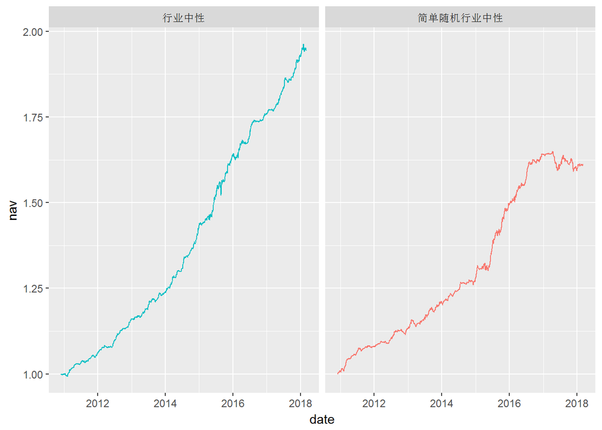

随机组合的历年alpha。

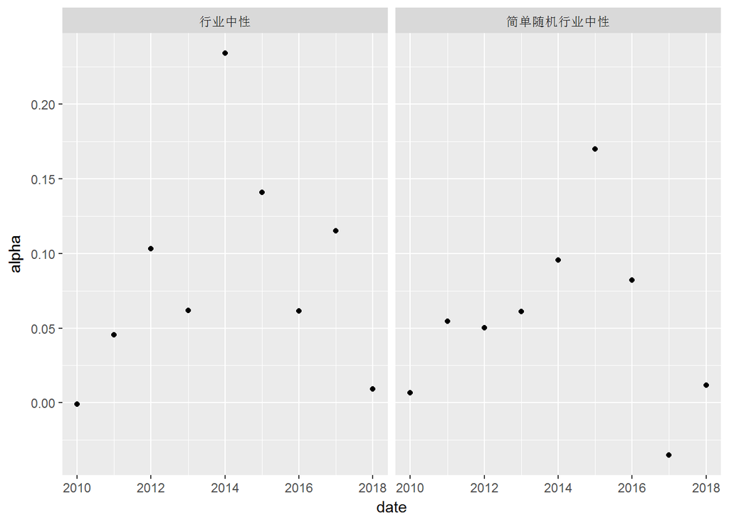

随机组合的历年日均偏离度。

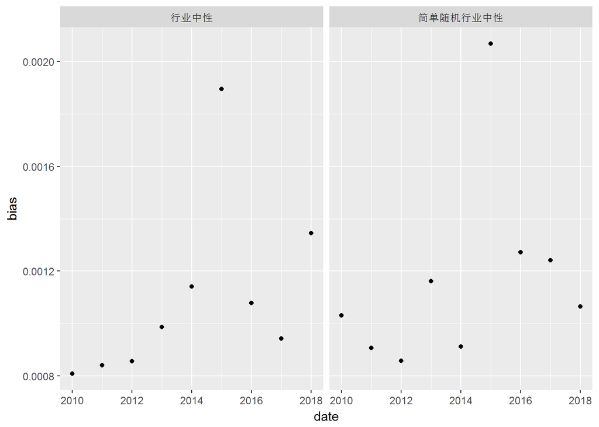

随机组合的历年年化跟踪误差。

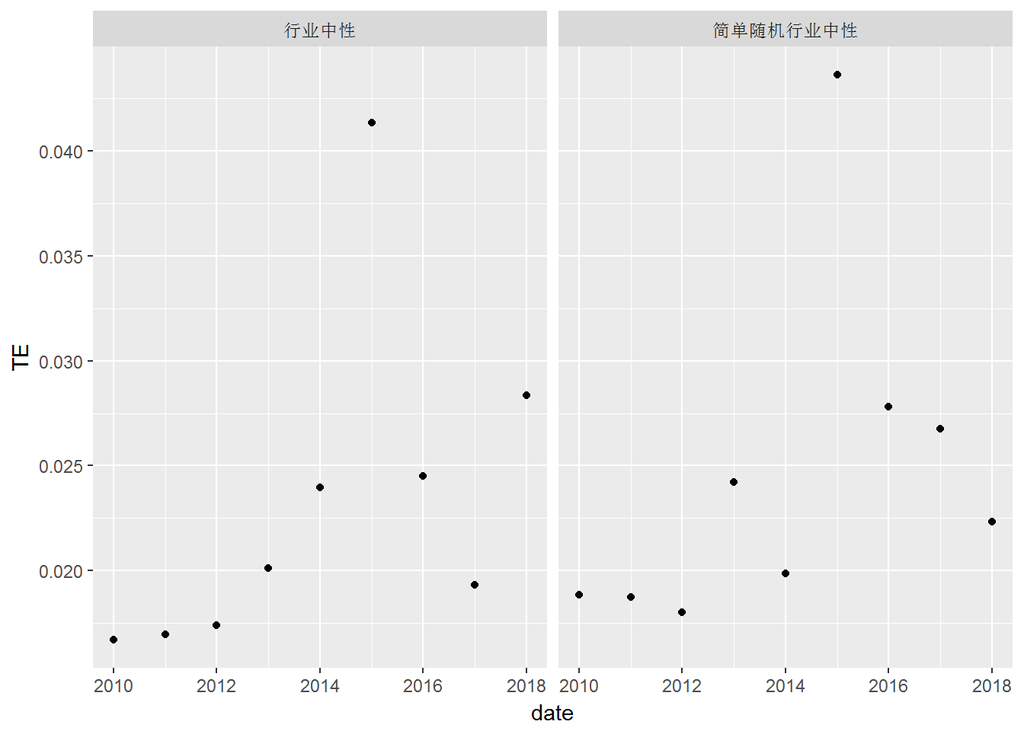

随机组合的历年alpha最大回撤。

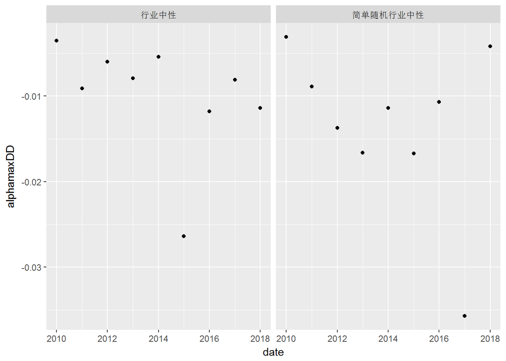

随机组合的收益统计如下表所示。

| type | fundID | rtn | rtn_ann | alpha | alpha_ann | hitratio | bias | TE | alphaIR | alphamaxDD | maxDDbegT | maxDDendT |
| --- | --- | --- | --- | --- | --- | --- | --- | --- | --- | --- | --- | --- |
| 简单随机行业中性 | hs300randsec_ | 105.5% | 10.4% | 76.8% | 6.9% | 57% | 0.0012 | 2.7% | 2.587 | -3.6% | 2017-04-12 | 2017-11-22 |
| 行业中性 | hs300sec_ | 146.3% | 13.2% | 117.6% | 9.7% | 61% | 0.0011 | 2.5% | 3.929 | -2.6% | 2015-08-11 | 2015-08-25 |

## 中证500随机组合

中证500随机组合和业绩基准的走势图如下所示。

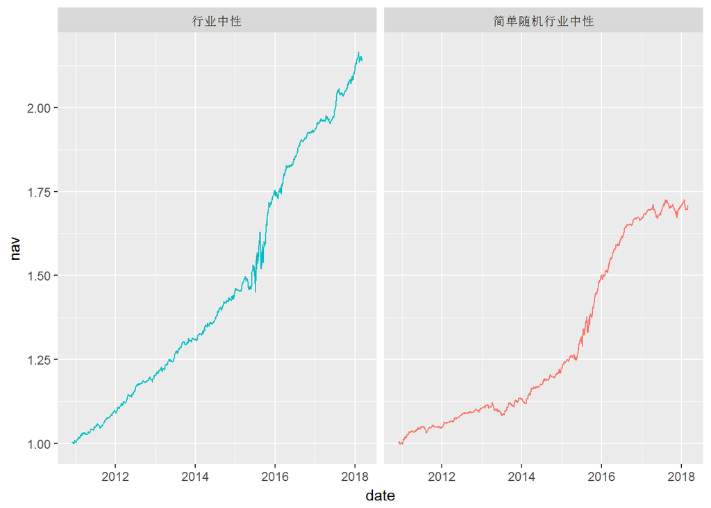

随机组合的历年alpha。

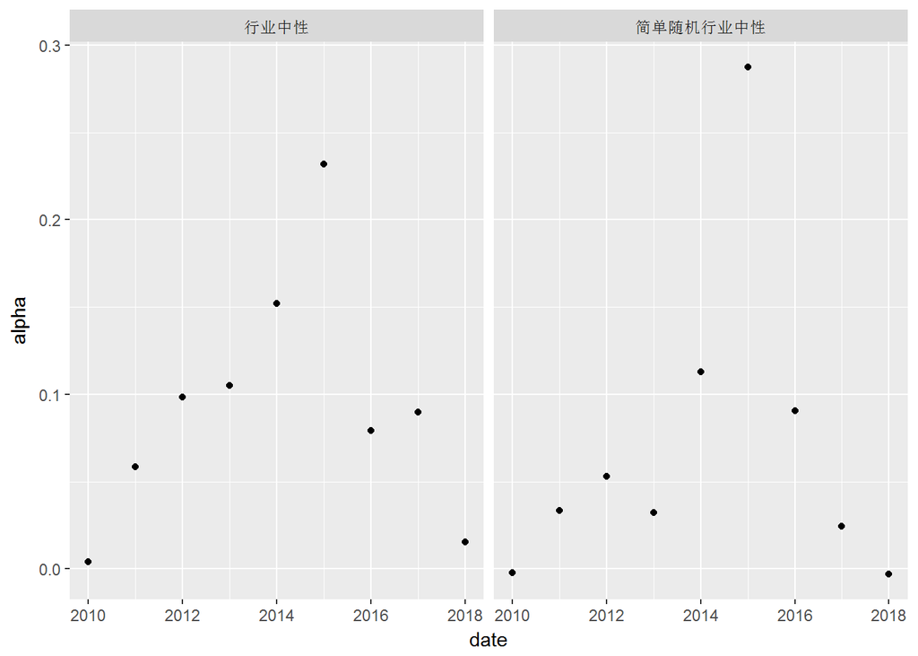

随机组合的历年日均偏离度。

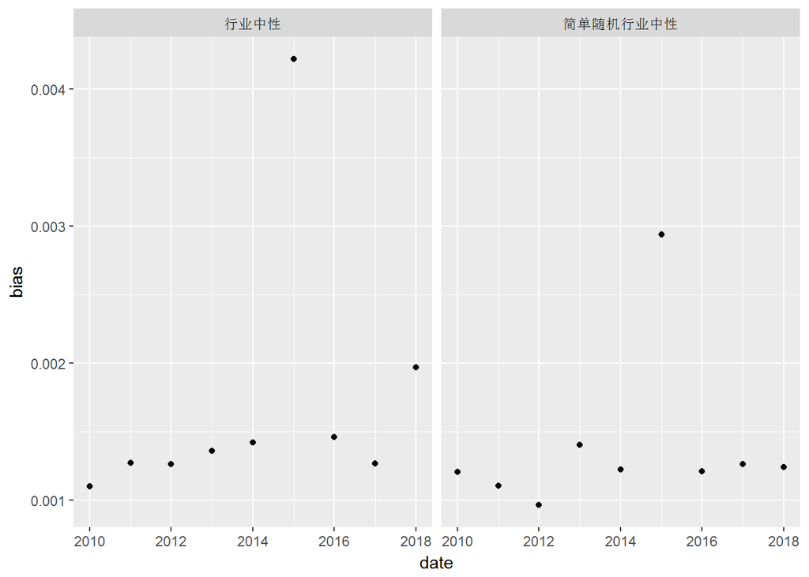

随机组合的历年年化跟踪误差。

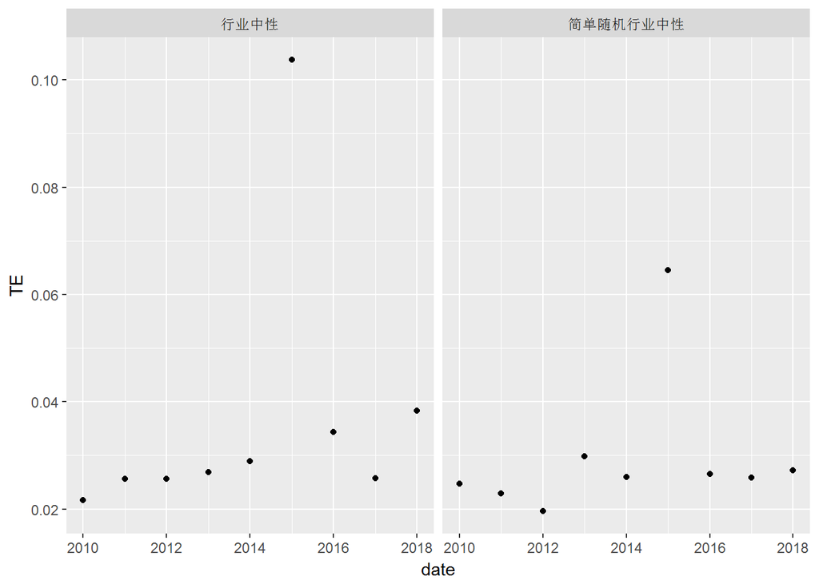

随机组合的历年alpha最大回撤。

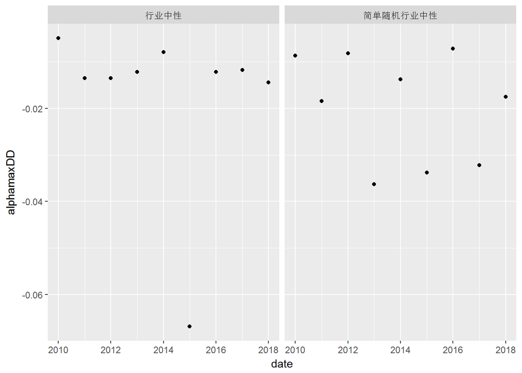

随机组合的收益统计如下表所示。

|  | type | fundID | rtn | rtn_ann | alpha | alpha_ann | hitratio | bias | TE | alphaIR | alphamaxDD | maxDDbegT | maxDDendT |
| --- | --- | --- | --- | --- | --- | --- | --- | --- | --- | --- | --- | --- | --- |
| 3 | 简单随机行业中性 | zz500randsec_ | 98.7% | 9.9% | 79.6% | 7.5% | 56% | 0.0014 | 3.4% | 2.229 | -3.6% | 2013-04-08 | 2013-07-03 |
| 4 | 行业中性 | zz500sec_ | 143.6% | 13.0% | 124.5% | 10.6% | 59% | 0.0017 | 4.7% | 2.276 | -6.7% | 2015-08-18 | 2015-08-26 |